# Q3: Psychological Distress, a UPF-Related Nutrient Proxy and Obesity

Findings, feasibility and next steps

STAT3888 Group 14

# 1 Direct answer

Among **non-pregnant Australians aged 18-64 in the 2011-12 surveys**, after accounting for age group and sex:

- **Psychological distress:** compared with low distress, obesity prevalence was about **23% higher with moderate distress**, **39% higher with high distress**, and **41% higher with very high distress**.
- **Dietary proxy:** each 10-percentage-point increase was associated with **14% higher relative obesity prevalence**.
- **Diabetes comparison:** The overall interaction is inconclusive. The moderate-versus-low contrast suggests a possible difference, but this is exploratory. Only **189 participants have diabetes**.

These are **separate associations from two surveys**, not independent effects in one combined model. The dietary measure is an **unvalidated UPF-related nutrient proxy, not actual UPF consumption**. The results describe existing obesity, not causes or future risk.

# 2 Findings

## 2.1 Psychological distress and obesity

K10 measures psychological distress over the preceding four weeks; it is not a diagnosis of depression. We use the supplied low, moderate, high and very-high categories, without assuming equally spaced effects. [ABS description of K10](https://www.abs.gov.au/ausstats/abs%40.nsf/Lookup/26DB864DADDA4011CA257AA30014BAA7).

| Comparison | Adjusted prevalence ratio (95% CI) | p-value |
| --- | --- | --- |
| Moderate vs low | 1.23 (1.10-1.38) | <0.001 |
| High vs low | 1.39 (1.20-1.60) | <0.001 |
| Very high vs low | 1.41 (1.17-1.70) | <0.001 |

The overall distress test gives **p < 0.001**. A ratio of 1 means no difference; 1.4 means 40% higher prevalence, **not** a 40-percentage-point increase or a 40% chance of becoming obese.

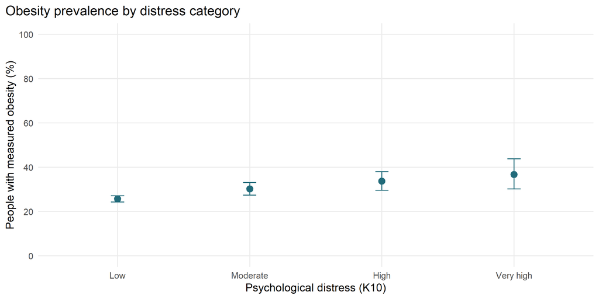

Figure 1. Survey-weighted obesity prevalence before age/sex adjustment, with 95% confidence intervals. The table above gives adjusted comparisons.

## 2.2 Nutrient proxy and obesity

We use the same definition as Q2: **energy percentage from saturated/trans fats plus added sugars** (`SATPER1 + PEADDSD1`). Trans fat is already included and is not added twice. This score can reflect nutrients in both UPF and non-UPF foods.

For each 10-percentage-point increase, the adjusted prevalence ratio is **1.14 (95% CI 1.07-1.20)**; **p < 0.001**. This repeats the shared dietary analysis, not independent confirmation of Q2. It does not establish an effect of UPF itself.

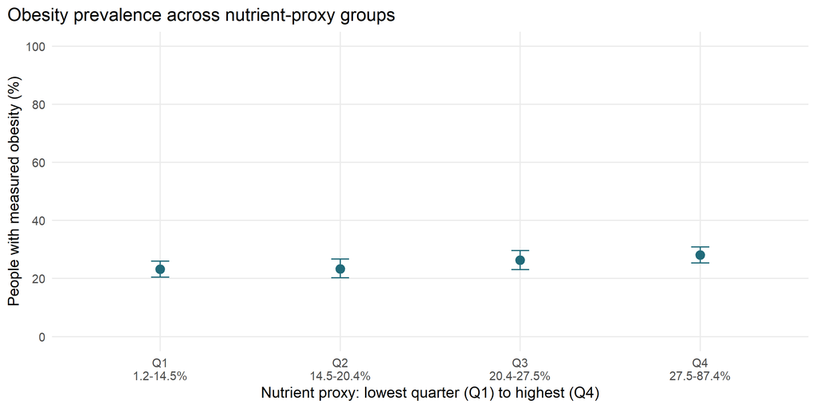

Figure 2. Survey-weighted obesity prevalence before age/sex adjustment, with 95% CIs. Quartiles split the NNPAS sample into roughly equal-sized groups. The adjusted model uses the numeric score.

## 2.3 Does the distress association differ by diabetes?

The primary interaction test gives **p = 0.0691**. It jointly compares the moderate-versus-low and high/very-high-versus-low associations between diabetes groups, **adjusting for age and sex only**. High and very-high distress are combined here, as in the earlier Q3 analysis, to limit parameters in the smaller diabetes sample.

| Group | Comparison | Adjusted prevalence ratio (95% CI) |
| --- | --- | --- |
| No diabetes | Moderate vs low | 1.25 (1.03-1.52) |
| No diabetes | High/very high vs low | 1.57 (1.28-1.91) |
| Diabetes | Moderate vs low | 0.75 (0.48-1.15) |
| Diabetes | High/very high vs low | 1.31 (1.01-1.70) |

One component is more suggestive: the **moderate-versus-low association is weaker with diabetes** (ratio of prevalence ratios **0.59 (95% CI 0.37-0.95)**; p = **0.0288**). This uncorrected, individual contrast is not the same as the overall two-part interaction test.

**Model caution:** the Poisson working model has 10 fitted probabilities slightly above 100% (maximum 102.1%). Its subgroup ratios need caution. The logistic alternative stays within 0-100% and also has an inconclusive overall interaction (**p = 0.0704**); it supplies the plot below.

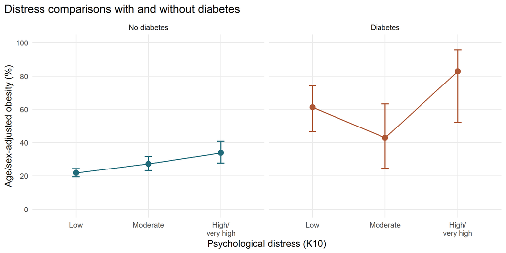

Figure 3. Logistic-model obesity probabilities standardized to the same age/sex distribution. Bars show 95% CIs. Different-looking lines or significance in only one group do not establish an interaction.

The table directly compares the changes shown in Figure 3: **change with diabetes minus change without diabetes**, in percentage points.

| Comparison | Difference in changes (95% CI) | p-value |
| --- | --- | --- |
| Moderate vs low | -23.9 (-47.5 to -0.3) | 0.0471 |
| High/very high vs low | +9.5 (-14.7 to +33.7) | 0.4348 |

The moderate-versus-low absolute contrast is borderline significant before multiple-testing correction. The plot’s **joint** absolute-difference test remains inconclusive (**p = 0.0603**). This differs from the primary ratio-scale test. The pattern merits follow-up, not a strong claim that the overall association differs or is identical.

# 3 Data and feasibility

The agreed question is feasible **as separate analyses**: distress-obesity and distress-by-diabetes in NHS, and nutrient-proxy-obesity in NNPAS. There is **no jointly observed complete dataset containing distress and the nutrient proxy**. Consequently, mutual adjustment, mediation and distress-by-diet interaction cannot be estimated here.

| Analysis | Complete n | Obese | Not obese | Obese: sample % | Obese: weighted % |
| --- | --- | --- | --- | --- | --- |
| Distress (NHS) | 10,264 | 2,894 | 7,370 | 28.2 | 27.5 |
| Nutrient proxy (NNPAS) | 6,244 | 1,664 | 4,580 | 26.6 | 25.2 |
| Distress by diabetes (NHS) | 4,059 | 1,183 | 2,876 | 29.1 | 25.6 |

The diabetes sample is a subset of the NHS sample; do not add these counts. Each analysis uses all eligible records with **its own required variables and valid survey weights**.

**Pregnancy is handled by restriction, not a model coefficient:** none of the 282 pregnant respondents aged 18-64 across the two surveys has usable measured BMI. The findings therefore do not cover pregnant adults. The outcome is **measured BMI >=30 kg/m²**, not waist circumference.

# 4 Interpretation and next steps

**Adjusted** means accounting for age and sex differences between groups. **Unadjusted** figures still use survey weights but do not account for those differences. Confidence intervals show sampling uncertainty, not all measurement error or bias.

Next, agree on additional confounders such as education, income, employment, smoking, physical activity and relevant medications where available; assess their timing before adding them. **These are candidates, not variables already adjusted for.** Examine missingness and influential weights. Check non-linearity using a spline for numeric K10 or the dietary score, and test alternative proxy definitions. Suitable methods include survey-weighted proportions, modified Poisson regression for prevalence ratios, logistic regression with standardized probabilities, and joint Wald interaction tests.

Cross-sectional measurements cannot establish which came first. Diabetes may follow obesity, so subgroup conditioning complicates causal interpretation. One-day diet, selective biomedical participation, missing BMI and the unvalidated proxy limit conclusions. Do not fill missing values with averages or select models to obtain small p-values.

**Technical details, cleaning and sensitivity checks**

## Variables and processing

[output not shown]

Raw files are unchanged. All 20,426 NHS and 12,153 NNPAS source rows remain in separate inclusion audits. The two NHS rows sharing a key are not identical person records: both remain in the standalone analysis. Both are excluded from biomedical linkage rather than guessing an assignment. No cross-survey person join is performed.

The proxy mean is 21.7% and median 20.4% in its analysis sample. No true UPF percentage is inferred from these summaries.

| survey | stage | n |
| --- | --- | --- |
| NHS | Original person rows | 20426 |
| NHS | Aged 18-64 | 12332 |
| NHS | Known non-pregnant | 12167 |
| NHS | Measured BMI available | 10290 |
| NHS | Complete primary model | 10264 |
| NNPAS | Original person rows | 12153 |
| NNPAS | Aged 18-64 | 7332 |
| NNPAS | Known non-pregnant | 7215 |
| NNPAS | Measured BMI available | 6246 |
| NNPAS | Complete primary model | 6244 |

| survey | variable | eligible_n | unavailable_n | unavailable_pct |
| --- | --- | --- | --- | --- |
| NHS | obese | 12167 | 1877 | 15.4 |
| NHS | distress | 12167 | 51 | 0.4 |
| NHS | diabetes | 12167 | 7913 | 65.0 |
| NNPAS | obese | 7215 | 969 | 13.4 |
| NNPAS | upf_nutrient_proxy_pct | 7215 | 4 | 0.1 |

| survey | pregnancy | n | measured_BMI_available |
| --- | --- | --- | --- |
| NHS | Not pregnant | 12167 | 10290 |
| NHS | Pregnant | 165 | 0 |
| NNPAS | Not pregnant | 7215 | 6246 |
| NNPAS | Pregnant | 117 | 0 |

| check | n |
| --- | --- |
| Repeated NHS person-key groups | 1 |
| Affected NHS person rows | 2 |
| Safely linked NHS person rows | 20424 |
| Eligible complete distress rows excluded by ID sensitivity | 0 |

| distress | n |
| --- | --- |
| Low | 7064 |
| Moderate | 2013 |
| High | 795 |
| Very high | 392 |

| diabetes | distress3 | n | obese_n | not_obese_n |
| --- | --- | --- | --- | --- |
| No diabetes | Low | 2641 | 655 | 1986 |
| No diabetes | Moderate | 793 | 248 | 545 |
| No diabetes | High/very high | 436 | 155 | 281 |
| Diabetes | Low | 117 | 78 | 39 |
| Diabetes | Moderate | 41 | 24 | 17 |
| Diabetes | High/very high | 31 | 23 | 8 |

Missingness counts overlap and must not be added. Unavailable diabetes includes absent biomedical measurements and ambiguous linkage. The diabetes model uses a selected biomedical subsample, not all NHS respondents with a self-reported diagnosis.

## Secondary checks

The ID check excludes 0 complete records: neither ambiguous-ID row entered the main analysis, so its unchanged result is an audit check rather than a distinct sensitivity sample. The grouping sensitivity retains all four distress categories in the diabetes interaction on the same 4059 participants. Its overall p-value is 0.133, again inconclusive. These checks do not select a grouping to obtain significance.

| Comparison | PR (95% CI) |
| --- | --- |
| Moderate vs low | 1.23 (1.10-1.38) |
| High vs low | 1.39 (1.20-1.60) |
| Very high vs low | 1.41 (1.17-1.70) |

| Check | n | p-value |
| --- | --- | --- |
| Distress: exclude ambiguous-ID rows | 10264 | <0.001 |
| Diabetes interaction: retain four distress categories | 4059 | 0.133 |

| model | n | converged | fitted_above_one |
| --- | --- | --- | --- |
| distress | 10264 | TRUE | 0 |
| diet | 6244 | TRUE | 0 |
| interaction | 4059 | TRUE | 10 |
| logistic | 4059 | TRUE | 0 |
| unambiguous | 10264 | TRUE | 0 |
| four_category | 4059 | TRUE | 5 |

All models converged with finite coefficients. Some modified Poisson fitted values exceed 1; inspect the diagnostic table and interpret their ratios cautiously. Figure 3 uses logistic probabilities bounded between 0 and 1. Secondary estimates and all tests are exploratory and not corrected for multiple comparisons.

Definitions were checked against the supplied `AHSnhsBasicCURFdataItemList.xlsx` (Health, Demographics, Physical measurements & Body Mass, Biomedical level) and `AHSnpaBasicCURFdataItemList.xlsx` (Risk factors - Nutrition, rows 183-184 and 219-220).

**R code behind confidence intervals and p-values**

These are the same code chunks executed for the report, displayed again without refitting. Run the Rmd from the beginning to create the cleaned objects. CIs are 95%; individual comparisons use two-sided tests. Point estimates, covariance and degrees of freedom all come from the fitted survey models, not rounded table values.

## Survey design and model formulas

NHS distress uses `NHSFINWT`, NNPAS diet uses `NPAFINWT`, and the NHS diabetes comparison uses `NHMSPERW`. Person replicate weights are `WPM0101-60`; biomedical replicate weights are `RPWGT01-60`. The 60 full-sample-centred jackknife replicates use multiplier 59/60. [ABS technical note](https://www.abs.gov.au/ausstats/abs%40.nsf/Lookup/4363.0.55.001Technical%2BNote12011-13).

```r
make_design <- function(d,weight,reps) {
  d <- d[is.finite(d[[weight]]) & d[[weight]]>0,,drop=FALSE]
  rw <- as.matrix(d[,reps,drop=FALSE])
  stopifnot(length(reps)==60L,all(is.finite(rw)),all(rw>=0))
  svrepdesign(data=as.data.frame(d),weights=reformulate(weight),repweights=rw,
    combined.weights=TRUE,type="other",scale=59/60,rscales=rep(1,60),mse=TRUE)
}
# Build full designs before selecting the eligible complete-case domains.
full_nhs <- make_design(nhs,"NHSFINWT",person_reps)
full_biomed <- make_design(nhs,"NHMSPERW",biomed_reps)
full_npa <- make_design(npa,"NPAFINWT",person_reps)
distress_design <- subset(full_nhs,distress_complete)
subgroup_design <- subset(full_biomed,subgroup_complete)
diet_design <- subset(full_npa,diet_complete)
unambiguous_design <- subset(full_nhs,unambiguous_complete)
cuts <- as.numeric(quantile(diet_design$variables$upf_nutrient_proxy_pct,seq(0,1,.25)))
stopifnot(length(unique(cuts))==5L)
diet_design <- update(diet_design,proxy_quartile=cut(upf_nutrient_proxy_pct,
  breaks=cuts,include.lowest=TRUE,labels=paste0("Q",1:4)))
```

```r
distress_formula <- obese~distress+age_group+sex
diet_formula <- obese~upf_nutrient_proxy_pct10+age_group+sex
interaction_formula <- obese~distress3*diabetes+age_group+sex
distress_model <- svyglm(distress_formula,distress_design,family=quasipoisson(link="log"))
diet_model <- svyglm(diet_formula,diet_design,family=quasipoisson(link="log"))
interaction_model <- svyglm(interaction_formula,subgroup_design,family=quasipoisson(link="log"))
logistic_model <- svyglm(interaction_formula,subgroup_design,family=quasibinomial())
# Targeted secondary checks: record ambiguity and distress-category grouping.
unambiguous_model <- svyglm(distress_formula,unambiguous_design,family=quasipoisson(link="log"))
four_category_model <- svyglm(obese~distress*diabetes+age_group+sex,
  subgroup_design,family=quasipoisson(link="log"))
```

The primary modified Poisson models estimate **prevalence ratios**, not odds ratios. Logistic regression is used for Figure 3. These are generalized linear models, not ANOVA or ordinary linear regression. Survey covariance replaces the naive independent-observation variance.

## Figures 1-2 and sample-summary CIs

For weighted prevalence `p`, compute its survey SE, transform it to the logit scale using `SE / (p * (1-p))`, apply a t critical value with `degf(design)`, then transform back to percentages.

```r
# Weighted prevalence and replicate-weight SE, with a logit-scale t interval.
prevalence <- function(ds) {
  z <- svymean(~obese,ds)
  p <- unname(coef(z)[1]); se <- unname(SE(z)[1])
  stopifnot(p>0,p<1)
  ci <- plogis(qlogis(p)+c(-1,1)*qt(.975,degf(ds))*se/(p*(1-p)))
  data.frame(n=nrow(ds$variables),obese_n=sum(ds$variables$obese),
    not_obese_n=sum(ds$variables$obese==0),sample_pct=100*mean(ds$variables$obese),
    weighted_pct=100*p,low=100*ci[1],high=100*ci[2])
}
by_group <- function(ds,variable) bind_rows(lapply(levels(ds$variables[[variable]]),
  function(g) cbind(group=g,prevalence(ds[ds$variables[[variable]]==g,]))))
distress_observed <- by_group(distress_design,"distress")
proxy_observed <- by_group(diet_design,"proxy_quartile")
proxy_observed$range <- sprintf("%.1f-%.1f%%",head(cuts,-1),tail(cuts,-1))
sample_table <- bind_rows(cbind(analysis="Distress (NHS)",prevalence(distress_design)),
  cbind(analysis="Nutrient proxy (NNPAS)",prevalence(diet_design)),
  cbind(analysis="Distress by diabetes (NHS)",prevalence(subgroup_design)))
```

## Adjusted ratios, subgroup CIs and initial tests

For contrast vector `L`, the log-ratio is `L' beta` and its SE is `sqrt(L' V L)`. Exponentiating the t interval yields a PR CI. Within the diabetes group, the contrast adds the relevant distress and interaction coefficients **including their covariance**. `regTermTest()` jointly tests all coefficients for a named term; the initial `svychisq()` tests are survey-adjusted Rao-Scott F tests without age/sex adjustment.

```r
# L selects a coefficient, sum, or difference. V includes survey covariance.
ratio_ci <- function(model,L) {
  stopifnot(identical(names(L),names(coef(model))))
  eta <- sum(L*coef(model)); se <- sqrt(as.numeric(t(L)%*%vcov(model)%*%L))
  crit <- qt(.975,model$df.residual)
  data.frame(ratio=exp(eta),low=exp(eta-crit*se),high=exp(eta+crit*se),
    p_value=2*pt(abs(eta/se),df=model$df.residual,lower.tail=FALSE),
    log_ratio=eta,SE=se,df=model$df.residual)
}
contrast <- function(model,terms) {
  L <- setNames(rep(0,length(coef(model))),names(coef(model)))
  stopifnot(all(terms %in% names(L))); L[terms] <- 1
  ratio_ci(model,L)
}
test_term <- function(model,term,label) {
  z <- regTermTest(model,term)
  data.frame(test=label,F_statistic=as.numeric(z$Ftest),numerator_df=z$df,
    denominator_df=z$ddf,p_value=as.numeric(z$p))
}
distress_results <- bind_rows(lapply(c("Moderate","High","Very high"),function(g)
  cbind(comparison=paste(g,"vs low"),contrast(distress_model,paste0("distress",g)))))
diet_result <- contrast(diet_model,"upf_nutrient_proxy_pct10")
within_diabetes <- function(model) bind_rows(lapply(c("No diabetes","Diabetes"),function(g)
  bind_rows(lapply(c("Moderate","High/very high"),function(level) {
    main <- paste0("distress3",level)
    terms <- c(main,if(g=="Diabetes") paste0(main,":diabetesDiabetes"))
    cbind(diabetes=g,comparison=paste(level,"vs low"),contrast(model,terms))
  }))))
subgroup_results <- within_diabetes(interaction_model)
model_tests <- bind_rows(
  test_term(distress_model,~distress,"Distress: adjusted overall test"),
  test_term(diet_model,~upf_nutrient_proxy_pct10,"Nutrient proxy: adjusted test"),
  test_term(interaction_model,~distress3:diabetes,"Distress by diabetes: PR scale"),
  test_term(logistic_model,~distress3:diabetes,"Distress by diabetes: OR scale"))
initial_test <- function(ds,var,label) {
  z <- svychisq(reformulate(c(var,"obesity_status")),ds,statistic="F")
  data.frame(test=label,F_statistic=unname(z$statistic),numerator_df=unname(z$parameter[1]),
    denominator_df=unname(z$parameter[2]),p_value=z$p.value)
}
initial_tests <- bind_rows(initial_test(distress_design,"distress","Distress categories: unadjusted"),
  initial_test(diet_design,"proxy_quartile","Proxy quartiles: unadjusted"))
```

|  | test | F_statistic | numerator_df | denominator_df | p_value |
| --- | --- | --- | --- | --- | --- |
| X-squared…1 | Distress categories: unadjusted | 8.8705 | 2.9321 | 172.9930 | 1.98804e-05 |
| X-squared…2 | Proxy quartiles: unadjusted | 2.3480 | 2.8902 | 170.5221 | 0.0767428 |
| …3 | Distress: adjusted overall test | 15.0400 | 3.0000 | 51.0000 | 3.87339e-07 |
| …4 | Nutrient proxy: adjusted test | 20.4291 | 1.0000 | 53.0000 | 3.50602e-05 |
| …5 | Distress by diabetes: PR scale | 2.8228 | 2.0000 | 49.0000 | 0.0691356 |
| …6 | Distress by diabetes: OR scale | 2.8024 | 2.0000 | 49.0000 | 0.0704111 |
| …7 | Joint difference in standardized prevalence changes | 2.9752 | 2.0000 | 49.0000 | 0.0603305 |

## Worked example: the two-coefficient diabetes interaction

Unlike Q2’s binary vitamin D exposure, Q3 has **two** interaction coefficients. The primary null is that both equal zero. With coefficient vector `b` and its covariance submatrix `V`, `F = (b' V^-1 b) / 2`, evaluated against an F distribution with 2 numerator degrees of freedom and the model’s residual denominator degrees of freedom. Testing one coefficient or comparing separate subgroup p-values would not answer the overall question.

```r
# Q3 has TWO interaction coefficients: jointly test both, not just one.
interaction_terms <- grep("^distress3.*:diabetesDiabetes$",names(coef(interaction_model)),value=TRUE)
b <- coef(interaction_model)[interaction_terms]
V <- vcov(interaction_model)[interaction_terms,interaction_terms,drop=FALSE]
q_df <- length(b)
wald_F <- as.numeric(t(b)%*%solve(V,b))/q_df
wald_p <- pf(wald_F,df1=q_df,df2=interaction_model$df.residual,lower.tail=FALSE)
stopifnot(q_df==2L,isTRUE(all.equal(wald_p,model_tests$p_value[3],tolerance=1e-10)))
interaction_components <- bind_rows(lapply(interaction_terms,function(term)
  cbind(term=term,contrast(interaction_model,term))))
interaction_worked <- data.frame(F=wald_F,df1=q_df,df2=interaction_model$df.residual,p_value=wald_p)
```

| Interaction term | Log ratio | SE | Ratio of PRs | CI low | CI high |
| --- | --- | --- | --- | --- | --- |
| distress3Moderate:diabetesDiabetes | -0.519412 | 0.230532 | 0.59487 | 0.374305 | 0.945407 |
| distress3High/very high:diabetesDiabetes | -0.175593 | 0.176853 | 0.83896 | 0.588022 | 1.196985 |

| F | df1 | df2 | p_value |
| --- | --- | --- | --- |
| 2.822799 | 2 | 49 | 0.069136 |

The two ratio-of-PR CIs above are individual contrasts, not a confidence region for the joint test. `regTermTest()` and the explicit matrix calculation are checked to agree.

## Figure 3: standardized probability CIs and absolute-difference tests

Each replicate refits the logistic model and reweights the **same reference age/sex distribution** for all six scenarios. `withReplicates()` retains the covariance between their logit probabilities and the absolute contrasts. Sparse diabetic cells may require extrapolation. Probability intervals are constructed on the logit scale; percentage-point contrast intervals are `estimate +/- t * SE`, with `2 * pt(abs(estimate / SE), df, lower.tail=FALSE)` p-values. The joint absolute test uses both differences-in-changes, not the primary PR-scale coefficients.

```r
# Scenario order: low/moderate/high-very-high without, then with diabetes.
scenarios <- expand.grid(distress3=c("Low","Moderate","High/very high"),
  diabetes=c("No diabetes","Diabetes"),stringsAsFactors=FALSE)
standardise <- function(w,data) {
  w <- as.numeric(w); data$.w <- w/mean(w)
  fit <- glm(interaction_formula,data=data,weights=.w,family=quasibinomial())
  stopifnot(fit$converged,all(is.finite(coef(fit))))
  p <- vapply(seq_len(nrow(scenarios)),function(i) {
    nd <- data
    nd$distress3 <- factor(scenarios$distress3[i],levels(data$distress3))
    nd$diabetes <- factor(scenarios$diabetes[i],levels(data$diabetes))
    weighted.mean(predict(fit,newdata=nd,type="response"),w)
  },numeric(1))
  delta <- 100*c(p[2]-p[1],p[3]-p[1],p[5]-p[4],p[6]-p[4])
  c(setNames(qlogis(p),paste0("scenario",1:6)),
    setNames(delta,c("moderate_no","high_no","moderate_yes","high_yes")),
    DID_moderate=delta[3]-delta[1],DID_high=delta[4]-delta[2])
}
# Each replicate refits AND reweights the common age/sex reference population.
std <- withReplicates(subgroup_design,standardise,return.replicates=TRUE)
theta <- coef(std); theta_se <- sqrt(diag(vcov(std)))
df_std <- logistic_model$df.residual; crit <- qt(.975,df_std)
std_prevalence <- scenarios
std_prevalence$prevalence <- 100*plogis(theta[1:6])
std_prevalence$low <- 100*plogis(theta[1:6]-crit*theta_se[1:6])
std_prevalence$high <- 100*plogis(theta[1:6]+crit*theta_se[1:6])
std_difference <- data.frame(contrast=c("Moderate - low: no diabetes","High/very high - low: no diabetes",
  "Moderate - low: diabetes","High/very high - low: diabetes",
  "Difference in changes: moderate vs low","Difference in changes: high/very high vs low"),
  percentage_points=unname(theta[7:12]),low=unname(theta[7:12]-crit*theta_se[7:12]),
  high=unname(theta[7:12]+crit*theta_se[7:12]),
  p_value=unname(2*pt(abs(theta[7:12]/theta_se[7:12]),df=df_std,lower.tail=FALSE)))
# Joint absolute-scale test: both differences-in-changes equal zero.
delta <- theta[11:12]; delta_V <- vcov(std)[11:12,11:12,drop=FALSE]
absolute_F <- as.numeric(t(delta)%*%solve(delta_V,delta))/length(delta)
absolute_test <- data.frame(test="Joint difference in standardized prevalence changes",
  F_statistic=absolute_F,numerator_df=length(delta),denominator_df=df_std,
  p_value=pf(absolute_F,length(delta),df_std,lower.tail=FALSE))
```

| distress3 | diabetes | prevalence | low | high |
| --- | --- | --- | --- | --- |
| Low | No diabetes | 21.82 | 19.42 | 24.42 |
| Moderate | No diabetes | 27.33 | 23.25 | 31.83 |
| High/very high | No diabetes | 34.00 | 27.79 | 40.80 |
| Low | Diabetes | 61.27 | 46.60 | 74.14 |
| Moderate | Diabetes | 42.89 | 24.60 | 63.35 |
| High/very high | Diabetes | 82.92 | 52.33 | 95.55 |

| contrast | percentage_points | low | high | p_value |
| --- | --- | --- | --- | --- |
| Moderate - low: no diabetes | 5.5183 | 0.5762 | 10.4605 | 0.0294 |
| High/very high - low: no diabetes | 12.1819 | 5.8143 | 18.5496 | 0.0003 |
| Moderate - low: diabetes | -18.3767 | -41.7298 | 4.9764 | 0.1202 |
| High/very high - low: diabetes | 21.6578 | -0.5742 | 43.8897 | 0.0560 |
| Difference in changes: moderate vs low | -23.8951 | -47.4744 | -0.3157 | 0.0471 |
| Difference in changes: high/very high vs low | 9.4758 | -14.7038 | 33.6555 | 0.4348 |

## Sensitivity calculations

These use the same CI and test helpers, with the secondary fits shown earlier.

```r
sensitivity_tests <- bind_rows(
  test_term(unambiguous_model,~distress,"Distress: exclude ambiguous-ID rows"),
  test_term(four_category_model,~distress:diabetes,"Diabetes interaction: retain four distress categories"))
sensitivity_tests$n <- c(nobs(unambiguous_model),nobs(four_category_model))
sensitivity_ratios <- bind_rows(lapply(c("Moderate","High","Very high"),function(g)
  cbind(comparison=paste(g,"vs low"),contrast(unambiguous_model,paste0("distress",g)))))
```

## Cleaning and linkage code

```r
pregnancy_status <- function(sex,stage) case_when(
  sex==1L ~ "Not pregnant", sex==2L & stage==2L ~ "Pregnant",
  sex==2L & stage %in% c(1,3:6) ~ "Not pregnant", TRUE ~ "Unknown")
obesity <- function(x) case_when(x %in% 7:9 ~ 1L,
  x %in% 1:6 ~ 0L,TRUE ~ NA_integer_)
common_clean <- function(d) d %>% mutate(
  pregnancy=pregnancy_status(SEX,FEMLSBC),
  sex=factor(if_else(SEX %in% 1:2,SEX,NA_integer_),1:2,c("Male","Female")),
  eligible=age_eligible & pregnancy=="Not pregnant",
  obese=obesity(BMICATHY),obesity_status=factor(obese,0:1,c("Not obese","Obese")))
age_labels <- c("18-24","25-34","35-44","45-54","55-64")
nhs <- nhs_source %>% mutate(age_eligible=AGEB %in% 5:14,
  age_group=factor(case_when(AGEB %in% 5:6 ~ "18-24",AGEB %in% 7:8 ~ "25-34",
    AGEB %in% 9:10 ~ "35-44",AGEB %in% 11:12 ~ "45-54",
    AGEB %in% 13:14 ~ "55-64",TRUE ~ NA_character_),age_labels),
  distress=factor(if_else(MNKESSGP %in% 1:4,MNKESSGP,NA_integer_),1:4,
    c("Low","Moderate","High","Very high")),
  distress3=factor(case_when(MNKESSGP==1L ~ "Low",MNKESSGP==2L ~ "Moderate",
    MNKESSGP %in% 3:4 ~ "High/very high",TRUE ~ NA_character_),
    c("Low","Moderate","High/very high")),
  k10_score=if_else(MNKESSLR %in% 10:50,as.numeric(MNKESSLR),NA_real_)) %>% common_clean()

# Reuse the agreed Q2 definition; the raw nutrient percentages are preserved.
source("../scripts/build_q2_upf_fat_sugar_proxy.R")
test_q2_fat_sugar_proxy()
proxy <- construct_q2_fat_sugar_proxy(npa_source)
npa <- npa_source %>% left_join(proxy %>% select(ABSPID,upf_nutrient_proxy_pct,
  upf_nutrient_proxy_pct10,proxy_status),by="ABSPID",relationship="one-to-one") %>%
  mutate(age_eligible=AGEC %in% 18:64,
    age_group=cut(AGEC,c(17,24,34,44,54,64),labels=age_labels)) %>% common_clean()
```

```r
# IDs are not unique for two NHS rows. Never guess a biomedical assignment.
keys <- c("ABSLID","ABSPID")
person_duplicates <- nhs %>% count(ABSLID,ABSPID) %>% filter(n>1)
bio_duplicates <- bio_source %>% count(ABSLID,ABSPID) %>% filter(n>1)
ambiguous_keys <- bind_rows(person_duplicates,bio_duplicates) %>% distinct(ABSLID,ABSPID)
nhs <- nhs %>% left_join(mutate(ambiguous_keys,ambiguous_key=TRUE),by=keys,
  relationship="many-to-one") %>% mutate(ambiguous_key=coalesce(ambiguous_key,FALSE))
safe_bio <- anti_join(bio_source,ambiguous_keys,by=keys)
linked <- nhs %>% filter(!ambiguous_key) %>% left_join(
  mutate(safe_bio,bio_matched=TRUE),by=keys,relationship="one-to-one")
stopifnot(nrow(linked)==sum(!nhs$ambiguous_key),all(linked$bio_matched))
# Attach safely linked fields by source row; retain every original person row.
nhs <- nhs %>% left_join(linked %>% select(source_row_id,DIABPRVE,NHMSPERW,
  all_of(biomed_reps),bio_matched),by="source_row_id",relationship="one-to-one") %>%
  mutate(diabetes=factor(case_when(DIABPRVE %in% 1:2 ~ "Diabetes",
    DIABPRVE %in% 3:4 ~ "No diabetes",TRUE ~ NA_character_),c("No diabetes","Diabetes")))
stopifnot(nrow(nhs)==nrow(nhs_source),identical(nhs$source_row_id,nhs_source$source_row_id),
  nrow(npa)==nrow(npa_source),identical(npa$ABSPID,npa_source$ABSPID))
complete_flag <- function(d,vars,weight) d$eligible &
  complete.cases(d[,vars,drop=FALSE]) & is.finite(d[[weight]]) & d[[weight]]>0
core <- c("obese","age_group","sex")
nhs$distress_complete <- complete_flag(nhs,c(core,"distress"),"NHSFINWT")
nhs$subgroup_complete <- complete_flag(nhs,c(core,"distress3","diabetes"),"NHMSPERW") &
  !nhs$ambiguous_key
nhs$unambiguous_complete <- nhs$distress_complete & !nhs$ambiguous_key
npa$diet_complete <- complete_flag(npa,c(core,"upf_nutrient_proxy_pct10"),"NPAFINWT")
```